# Open Data v1

Michael Anderson

3/22/2022

## NYC OpenData

NYC Open Data is a large collection of free data sets published by the City of New York. These tables and resources can be used to understand how the city operates. There are a lot of great resources you can use to understand the history of OpenData and the basics you’ll need to perform operations on datasets.

[BetaNYC](https://beta.nyc/) has some great resources, including an Open Data 101 course called [Introduction to Open Data](http://bit.ly/BetaNYC_Mozfest), which has a great section on the history of OpenData in NYC.

I’m going to access these datasets using R/RStudio using Socrata URL queries. Other authors use Python for their projects, and many of these seem to use more explicit HTTP methods to access data.

[OpenData](https://opendata.cityofnewyork.us/) provides a number of useful [“how-to”](https://opendata.cityofnewyork.us/how-to/) pages to help you:

1. [Get started](https://dev.socrata.com/consumers/getting-started.html),
2. Set up [URL queries](https://dev.socrata.com/docs/queries/), and
3. Navigate [API endpoints](https://dev.socrata.com/docs/endpoints.html).

## Project Overview

The aim of this analysis is to provide a high-level overview of NYC OpenData. To start our investigation we will do some basic data cleaning, followed by a review available datasets. Then I’ll briefly explore what agencies publish the most data, what datasets are the most popular, and which datasets are the largest. I’ll conclude with next steps and present some ideas for how to improve future investigations.

### Table Inventory

A great place to gets started is with a review of the [Local Law 251 of 2017: Published Data Asset Inventory](https://data.cityofnewyork.us/resource/5tqd-u88y). This table contains information on all the datasets hosted in NYC OpenData, and allows us to see which datasets are the most popular or which agencies are open data champions. To start this review let’s set up our workspace.

```r
# In a regular script I frequently cleanup my workspace before working.
#rm(list=ls())

# The libraries I'll use for this project. I'm going to suppress all the normal warnings these packages typically create.
suppressWarnings(suppressPackageStartupMessages({
  library(RSocrata)
  library(jsonlite)
  library(tidyverse)
  library(ggplot2)
  library(waffle)
  library(ggpubr)
  library(httr)
  library(kableExtra)
  library(knitr) # tables & formating
  library(magrittr) # tables & formating
  library(visdat) # large table summary
  library(DT) # html widgets
}))

# In a regular script I would also include these two commands to set my working directory.
script_name <- rstudioapi::getSourceEditorContext()$path
setwd(dirname(script_name))

# My token for Socrata, in case I'm throttled.
token <-"***************************"
```

Now let’s start our review of all the Published Data Asset Inventory. Two things to note:

1. I haven’t used my token and I’m not limited to some finite number rows in this pull, nor do I have to skip my way through to pull all the rows. This is a little different from Python, which seems to require skipping through the dataset to download all rows.
2. I also shortened column names as much as practically possible.

```r
# Local Law 251 of 2017: Published Data Asset Inventory
all_open_data_sets <- "https://data.cityofnewyork.us/resource/5tqd-u88y.json?$select=*"
all_open_data_sets <- read.socrata(all_open_data_sets)

# I'm going to rename these columns so they take up less space.
rename(all_open_data_sets,
        data.agency = datasetinformation_agency,
        uid = uid,
        name = name,
        description = description,
        type = type,
        category = category,
        from.opendata.plan = legislativecompliance_datasetfromtheopendataplan,
        url = url,
        date.public = update_datemadepublic,
        update.freq = update_updatefrequency,
        last.update = last_data_updated_date,
        can.automate = legislativecompliance_candatasetfeasiblybeautomated,
        automated = update_automation,
        has.dictionary = legislativecompliance_hasdatadictionary,
        contain.address = legislativecompliance_containsaddress,
        geo.coded = legislativecompliance_geocoded,
        exists.externally = legislativecompliance_existsexternallyll1102015,
        external.freq = legislativecompliance_externalfrequencyll1102015,
        records.removed = legislativecompliance_removedrecords,
        visits = visits,
        row.count = row_count,
        column.count = column_count,
        derived.view = derived_view,
        parent.uid = parent_uid) -> all_open_data_sets
```

### Table Summary

Here’s a quick peak at first values from this table. Nothing unusual here - the table is small (about 3400 rows and 2 dozen columns), most fields are formatted as character (including numbers), and around one-third of the dataset contains binary values.

```
## Rows: 3,493
## Columns: 24
## $ data.agency        <chr> "Department of Information Technology & Telecommuni…
## $ uid                <chr> "kvfi-kxcq", "cz36-mpdq", "uchs-jqh4", "fxwm-3t4n",…
## $ name               <chr> "2008 Orthoimagery Bronx", "2006 - 2011 English Lan…
## $ description        <chr> "The Department of Information Technology and Telec…
## $ type               <chr> "href", "dataset", "dataset", "dataset", "href", "f…
## $ category           <chr> "City Government", "Education", "Education", "Educa…
## $ from.opendata.plan <chr> "NO", "No", "Yes", "No", "NO", "NO", "NO", "NO", "N…
## $ url                <chr> "https://data.cityofnewyork.us/d/kvfi-kxcq", "https…
## $ date.public        <chr> "8/3/2017", "10/11/2011", "8/3/2017", "2/21/2013", …
## $ update.freq        <chr> "Historical Data", "Historical Data", "Historical D…
## $ last.update        <dttm> 2017-08-03 14:27:44, 2011-10-05 20:39:42, 2017-08-…
## $ can.automate       <chr> "No", "No", "No", "No", "No", "No", "No", "No", "No…
## $ automated          <chr> "No", "No", "No", "No", "No", "No", "No", "No", "No…
## $ has.dictionary     <chr> "Yes", "Yes", "Yes", "Yes", "Yes", "Yes", "Yes", "Y…
## $ contain.address    <chr> "No", "No", "No", "No", "No", "No", "No", "No", "Ye…
## $ geo.coded          <chr> "N/A", "N/A", "N/A", "N/A", "N/A", "N/A", "N/A", "N…
## $ exists.externally  <chr> "No", "No", "No", "No", "No", "No", "No", "No", "Ye…
## $ external.freq      <chr> "N/A", "N/A", "N/A", "N/A", "N/A", "N/A", "N/A", "N…
## $ records.removed    <chr> "No", "No", "No", "No", "No", "No", "No", "No", "No…
## $ visits             <chr> "93", "293", "257", "440", "88", "110", "139", "105…
## $ derived.view       <chr> "FALSE", "FALSE", "FALSE", "FALSE", "FALSE", "FALSE…
## $ row.count          <chr> NA, "5376", "1571", "49", NA, NA, NA, NA, "2646", "…
## $ column.count       <chr> NA, "16", "3", "15", NA, NA, NA, NA, "57", "45", "5…
## $ parent.uid         <chr> NA, NA, NA, NA, NA, NA, NA, NA, NA, NA, NA, NA, NA,…
```

#### Sample Data

Here’s a quick peak at some of the first values from this table.

|  | data.agency | uid | name | description | type | category | from.opendata.plan | url | date.public | update.freq | last.update | can.automate | automated | has.dictionary | contain.address | geo.coded | exists.externally | external.freq | records.removed | visits | derived.view | row.count | column.count | parent.uid |
| --- | --- | --- | --- | --- | --- | --- | --- | --- | --- | --- | --- | --- | --- | --- | --- | --- | --- | --- | --- | --- | --- | --- | --- | --- |
| 2 | Department of Education (DOE) | cz36-mpdq | 2006 - 2011 English Language Arts (ELA) Test Results by Grade - District - by Race-Ethnicity | New York City Results on the New York State English Language Arts (ELA) Tests, Grades 3 - 8 Notes: As of 2006, the New York State Education Department expanded the ELA and mathematics testing programs… | dataset | Education | No | https://data.cityofnewyork.us/d/cz36-mpdq | 10/11/2011 | Historical Data | 2011-10-05 20:39:42 | No | No | Yes | No | N/A | No | N/A | No | 293 | FALSE | 5376 | 16 | NA |
| 5 | Department of Information Technology & Telecommunications (DoITT) | bzri-pz9j | 2010 Orthoimagery Queens - 1 of 2 | The Department of Information Technology and Telecommunications, GIS Unit, is providing the raw orthoimagery for download. This orthoimagery is used to create the Aerial Photography Tile Layer service… | href | City Government | NO | https://data.cityofnewyork.us/d/bzri-pz9j | 8/3/2017 | Historical Data | 2017-08-02 22:01:33 | No | No | Yes | No | N/A | No | N/A | No | 88 | FALSE | NA | NA | NA |
| 17 | Department of Education (DOE) | 5qza-frfc | 2013-2017 District ELA Results - Gender |  | dataset | Education | Yes | https://data.cityofnewyork.us/d/5qza-frfc | 9/25/2017 | Historical Data | 2017-09-25 15:38:51 | No | No | Yes | No | N/A | No | N/A | No | 190 | FALSE | 2240 | 16 | NA |

#### A `visdat` Graphic of Missing Data

There’s not a lot of data missing here, but two columns stick out - row.count and column.count. Roughly a quarter of these values are missing. We’ll dig into this a bit more later. The field parent.uid is also mostly empty. We’ll also dig into this later too, our fix for these missing values is connected to the missing row/column values.

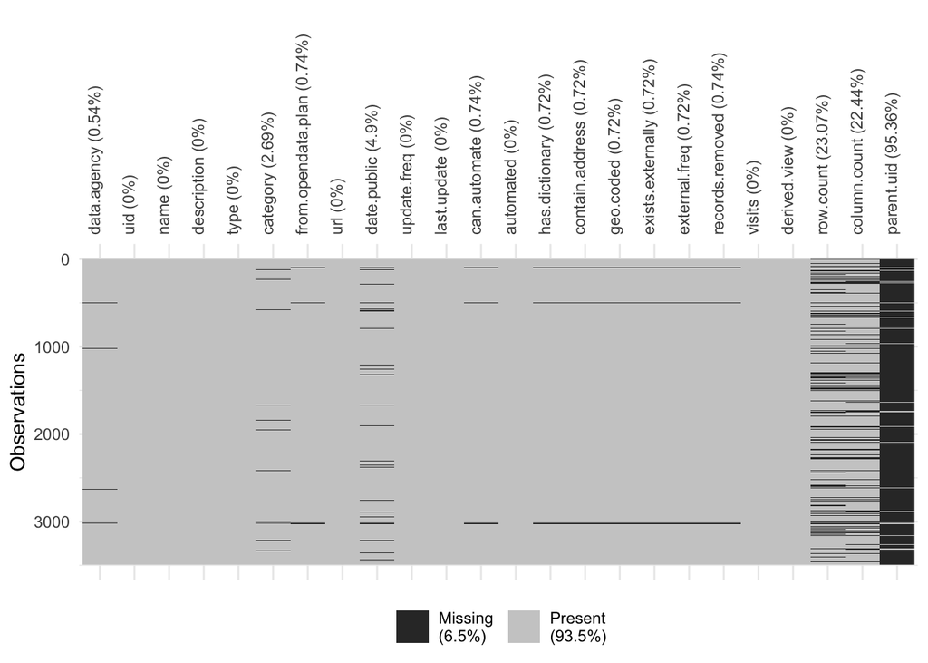

#### Review of the *Published Data Asset Inventory* Table

This table being reviewed - Published Data Asset Inventory - has data formatting problems that we’ll fix and some that we won’t. Most issues are related to the consistent use of “Yes” and “No”, and a few are connected to missing data.

[output not shown]

### Data Cleaning

Key Steps

1. Create a shorter version of the variable `data.agency`.
2. Clean Yes/No variables.
3. Convert text to numbers.
4. Locate missing row and column number values.

#### Step 1 - Simplify `data.agency`

```r
# Recode NA as missing.
all_open_data_sets$data.agency <- trimws(ifelse(is.na(all_open_data_sets$data.agency),
                                                              "Missing",all_open_data_sets$data.agency))
# Extract short name for graphing.
all_open_data_sets$dataset.owner <- stringr::str_extract(string =  all_open_data_sets$data.agency,
                                                         pattern = "(?<=\\().*(?=\\))")

# Shorten names for graphing, and reorder columns so the short, abbreviation "dataset.owner" is next to full name "data.agency".
all_open_data_sets %>%
  mutate(dataset.owner =
     case_when(
      data.agency == "Other" ~ 'OTHER',
      data.agency == "Mayor's Office of Climate and Sustainability" ~ "SUSTAIN",
      data.agency == "Mayor's Office for Economic Opportunity" ~ "ECON-OPP",
      data.agency == "Mayor’s Office to End Domestic and Gender-Based Violence" ~ "END-GBV",
      data.agency == "Missing" ~ "Missing",
      data.agency == "311" ~ "311",
      data.agency == "Mayor's Office of Climate Resiliency" ~ "CLIMATE",
      data.agency == "Civil Service Commission" ~ "CSC",
      data.agency == "NYC Health + Hospitals" ~ "H+H",
      data.agency == "Public Design Commission (formerly Art Commission (ARTCOM) and Design Commission)" ~ "PDC",
      data.agency == "HHS Accelerator" ~ "HHS-ACCEL",
      data.agency == "Mayor's Office of Climate Policy and Programs" ~ "CLIMATE-POLICY",
      data.agency == "NYC Recovery" ~ "RECOVERY",
       TRUE ~ dataset.owner)) %>%
  relocate(dataset.owner, .after = data.agency) -> all_open_data_sets
```

#### Step 2 - Clean Yes/No Data

The yes/no fields contain inconsistently formatted values. For example, `unique(all_open_data_sets$from.opendata.plan)` returns this list of variants like “NO”, “Yes”, “No”, “YES”, “N/A”, and NA. If the yes/no data was clean we’d see a clean split, but we don’t. There’s actually a medium amount of variation in yes/no values. While it’s true that there are no simple `T` or `F` values, we have just about every other version of `Yes` and `No` present. Let’s clean these.

Dirty Yes/No Data

| yes_no | count |
| --- | --- |
| No | 12716 |
| Yes | 6762 |
| N/A | 3084 |
| NO | 833 |
| YES | 707 |
|  | 194 |
| NA | 153 |
| yes | 2 |

```r
# Clean yes/no values
dirty <-  c(NA ,""  ,"N/A","No","NO","yes","Yes","YES")
clean <- c("NO","NO","NO" ,"NO","NO","YES","YES","YES")
all_open_data_sets$from.opendata.plan <- clean[match(all_open_data_sets$from.opendata.plan,dirty)]
all_open_data_sets$records.removed <- clean[match(all_open_data_sets$records.removed,dirty)]
all_open_data_sets$exists.externally <- clean[match(all_open_data_sets$exists.externally,dirty)]
all_open_data_sets$can.automate <- clean[match(all_open_data_sets$can.automate,dirty)]
all_open_data_sets$automated <- clean[match(all_open_data_sets$automated,dirty)]
all_open_data_sets$has.dictionary <- clean[match(all_open_data_sets$has.dictionary,dirty)]
all_open_data_sets$contain.address <- clean[match(all_open_data_sets$contain.address,dirty)]
all_open_data_sets$geo.coded <- clean[match(all_open_data_sets$geo.coded,dirty)]

# There are too many Yes/No variants. Let's find all possible variations of in the Yes/No variables.
yes_no <- c(unlist(all_open_data_sets$from.opendata.plan),
            unlist(all_open_data_sets$records.removed),
            unlist(all_open_data_sets$can.automate),
            unlist(all_open_data_sets$automated),
            unlist(all_open_data_sets$has.dictionary),
            unlist(all_open_data_sets$contain.address),
            unlist(all_open_data_sets$geo.coded))

# The combined list of *clean* Yes/No options.
yes_no <-  as.data.frame(yes_no)
names(yes_no) <- 'yes_no'
yes_no %>% group_by(yes_no) %>% summarize(count=n()) %>% arrange(desc(count))-> new_yes_no_summary
```

With clean `YES` and `NO` values, the table is smaller and contains just two rows.

Cleaned Yes/No Data

| yes_no | count |
| --- | --- |
| NO | 16980 |
| YES | 7471 |

#### Step 3 - Text to Numbers

Now we will explicitly convert visits to numbers.

```r
# Code visits, columns, and rows as numbers (a very short step)
all_open_data_sets$visits <- as.numeric(all_open_data_sets$visits)
all_open_data_sets$row.count <- as.numeric(all_open_data_sets$row.count)
all_open_data_sets$column.count <- as.numeric(all_open_data_sets$column.count)
```

#### Step 4 - Locate Missing Row/Column Data

The asset inventory table contains some fun descriptive measures like the amount of data published by each agency, the number of times a dataset has been visited, and the number of datasets published by each agency. While reviewing the amount of data published by each agency I noticed a problem - some datasets were missing a count of rows and columns. I happened to stumble across this while reviewing data for the TLC. Here’s an example.

```r
# Matrix size of each dataset
all_open_data_sets$size <- as.numeric(all_open_data_sets$row.count) * as.numeric(all_open_data_sets$column.count)

# An example of missing size data
all_open_data_sets %>%
  dplyr::select(dataset.owner,uid,name,type,visits,row.count,column.count,derived.view,parent.uid,size) %>%
  filter(uid %in% c('5gj9-2kzx','7rnv-m532')) -> size_example
```

Here are two tables, one with a row/column count and one without. We can take a look at whether this information is really missing in OpenData using the uid (or parent.uid) for each table. The URL pattern to follow is `valid_url` = `root_url` + `uid`, where the `root_url` = *https://data.cityofnewyork.us/resource/*.

| dataset.owner | uid | name | type | visits | row.count | column.count | derived.view | parent.uid | size |
| --- | --- | --- | --- | --- | --- | --- | --- | --- | --- |
| TLC | 5gj9-2kzx | 2017 Green Taxi Trip Data | dataset | 4450 | 11740667 | 19 | FALSE | NA | 223072673 |
| TLC | 7rnv-m532 | 2013 Yellow Taxi Trip Data | datalens | 3639 | NA | NA | TRUE | t7ny-aygi | NA |

Casual observation - some reason older tables, especially ones that have a parent.uid listed, are missing row and column counts. At the time I saw this I was bothered by the error and went down a rabbit hole looking into it. I still don’t know why the problem exits, but I have a solution - when row and column counts are missing, and a parent.uid is present, use the row/column counts of the parent.uid. Based on my review, `parent.uid` references the same dataset as the `uid` record, but with more metadata in a computer friendly format.

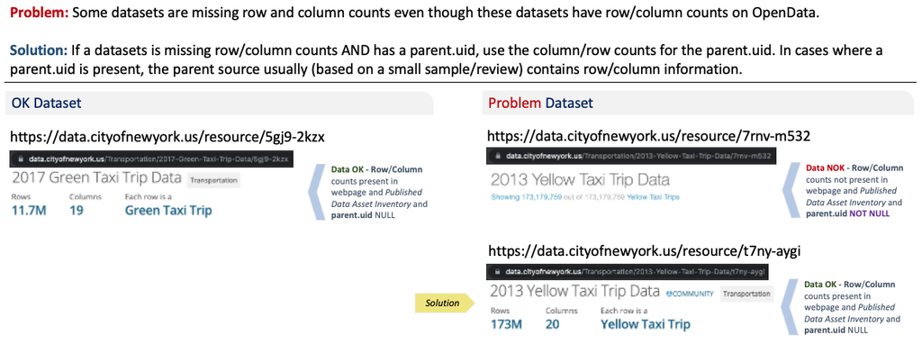

##### Using `uid` and `parent.uid` to Locate Row/Column Data

Now that I have an idea for how to fix the problem, let’s go about solving the issue. I started by creating a list possible URL and then looped through them. My first approach was to using queries to pull missing row and column values. To find the number of columns, I would select 1 row from a dataset using `limit 1` in my URL SoQL query, and to find the number of rows I used a `count(*)`. I pulled column and row counts for every table, compared them with the OpenData values in the source dataset, and reviewed a sample of discrepancies.

In many cases I was able to fill in gaps in information. However, in a few cases I found errors that were the result of bad assumptions on my part. For these errors, my row counts were fine but a the column counts were off. Why? Occasionally the first row of a dataset was missing values and so a subset of total columns were returned from my `limit 1` and I recorded the subset as the actual column number. The fast (and inefficient) solution was to expand my limit to some larger number, I chose 200 records, and hope that the larger number ensured a complete set of columns for at least one row. However, this solution dramatically increased the time needed to run the loop.

In the end I compromised and used a combination of `http` and `query` methods. First, I counted the field types returned in the HTTP header. If the header didn’t included headers then I would move onto step two and count columns after querying the first 200 rows (`limit 200`). I used a try-catch function to split the work into the first/second buckets, and handle errors that would otherwise cause the script to stop. The script still takes a solid hour or two to run.

I also ran the loop a few times to fix problems. I would cut the loop down to 5 or 10 records before expanding the range to include all tables. I ran the full loop a few times, saved the data, and loaded it in separately in this markdown to speed up the rendering of the final HTML (which is this one, the one you are reading). The size loop required around 1.5 hours to complete.

```r
# Let's form new URLs - use the parent.uid when it's present, otherwise use the uid.
all_open_data_sets %>%
  mutate(new.uid = case_when(is.na(parent.uid) ~ uid,TRUE ~ parent.uid)) %>%
  mutate(new.url = paste0("https://data.cityofnewyork.us/resource/",new.uid,".json")) -> all_open_data_sets

# Create empty columns to hold new row/column data
all_open_data_sets$column.new <- ""
all_open_data_sets$row.new <- ""

# Turn off warnings - there are a number of inconsequential conversion errors at the end that
# don't affect the results and just make things look messy.
defaultW <- getOption("warn")
options(warn = -1)

# ----[ START loop ]----
for (i in 1:nrow(all_open_data_sets)){

  # Get http data for url
  t0 <- all_open_data_sets$new.url[i]
  t1 <- GET(t0)

  # If status is OK then let's get the number of COLUMNS
  if(t1$status_code==200){

    t2 <- tryCatch({
      length(fromJSON(t1$headers[["x-soda2-types"]])) # Use the http header FIRST
    }, warning = function(w) {
      print('warning')
    }, error = function(e) {
      ncol(read.socrata(paste0(t0,'?$limit=200'),token)) # Use the first 200 rows SECOND
    }, finally = {
    })

    t2 <- ifelse(is.null(t2),NA,t2) # If no data is there (in the case of a map uid, for example),
                                    # enter NA for the number of columns
    all_open_data_sets$column.new[i] <- t2

    u1 <- read.socrata(paste0(t0,'?$select=count(*)'),token) # Read the number of rows
    all_open_data_sets$row.new[i] <- u1[[1]]

    cat("\r main ok",i,rep(" ",150)) # A counter I can use to track progress
  }
  else { # If the first step fails, use NA for both row/column values
    all_open_data_sets$column.new[i] <- NA
    all_open_data_sets$row.new[i] <- NA

    cat("\r else na",i,rep(" ",150)) # Another counter to track progress
  }
}
# ----[ STOP loop ]----

# Turn warnings back on
options(warn = defaultW)

# write data
#write.csv(all_open_data_sets,"all_open_data_sets_STEP_17_DATA_2022-03-05.csv")
```

Let’s calculate new size values using our old and new row/column counts.

```r
# Size = ROW * COLUMN = Total cells | Size calculation using old, provided values.
ifelse(is.na(all_open_data_sets$row.count) | is.na(all_open_data_sets$column.count), NA,
       as.numeric(all_open_data_sets$row.count)*as.numeric(all_open_data_sets$column.count)) ->
  all_open_data_sets$old.size

# Size calculation using new, recently pulled values.
ifelse(is.na(all_open_data_sets$row.new) | is.na(all_open_data_sets$column.new), NA,
       as.numeric(all_open_data_sets$row.new)*as.numeric(all_open_data_sets$column.new)) ->
  all_open_data_sets$new.size
```

New vs Old Size Data

| Summary | Count |
| --- | --- |
| new_BIGGER_old | 47 |
| new_SAME_old | 2251 |
| new_SMALLER_old | 319 |
| new_NA_old_NOT | 25 |
| new_NOT_old_NA | 213 |
| new_NA_old_NA | 638 |

Let’s see how our size estimates changed after updating our row/column values. The results are, frankly, mixed. I made two types of comparisons: (1) existing tables that changed size, and (2) tables that came into (or left) existences.

### Basic Data Analysis

#### Size Improvements - New Row/Column Values vs Old Row/Column Values

The dataset sizes are very skewed. A regular histogram of the data is basically unreadable (see the *Histogram of As-Is Size Data*). All the values are clustered around the low end, with a smaller group of extreme values trailing out to the right. A log transformation makes the distribution much easier to interpret.

Why did I choose a base 2 log transform? Because it allows for easier “memory” comparisons. The size figures might represent a minimum data size: 1 cell = 1 byte (yes, I know 8 bits = 1 byte). Computer memory is described using base 2 units. For example, there are 2<sup>10</sup> MB to 1 GB, and 2<sup>10</sup> GB (or 2<sup>20</sup> MB) to 1 TB. So by transforming the date using a base 2 logarithm, the differences in orders of magnitude begin to match the order of magnitude differences in data.

```
Kilobyte (KB)   = 1,024 Bytes
Megabyte (MB)   = 1,024 Kilobytes
Gigabyte (GB)   = 1,024 Megabytes
Terabyte (TB)   = 1,024 Gigabytes
Petabyte (PB)   = 1,024 Terabytes
```

We can see the modest improvement in size data. The new size data is blue, and the old size data is red. This means that whenever a blue bar appears higher than a red bar, we have found new row/column values that weren’t there before.

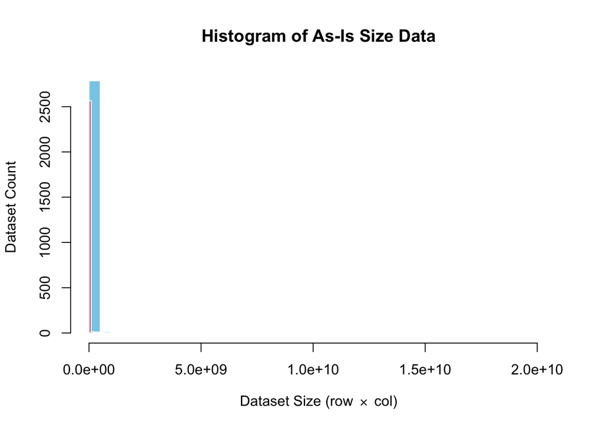

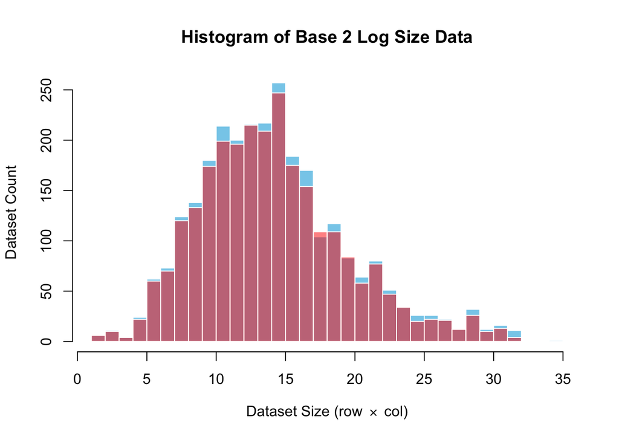

We see similar results with a line graph too - wherever light red appears this means new information has been found, while light blue means our new size is lower than the old one. The raw data is highly concentrated at the low end, but the log transform is more normal looking.

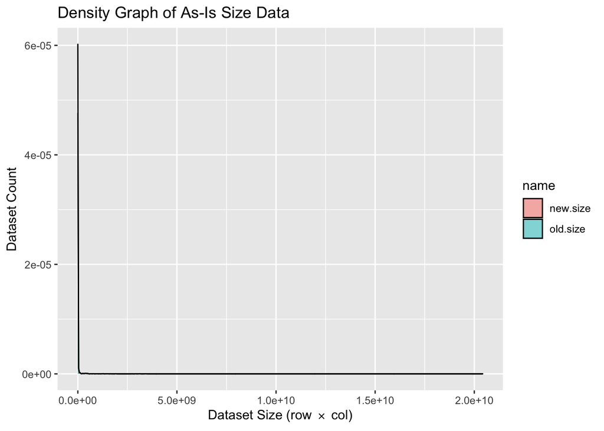

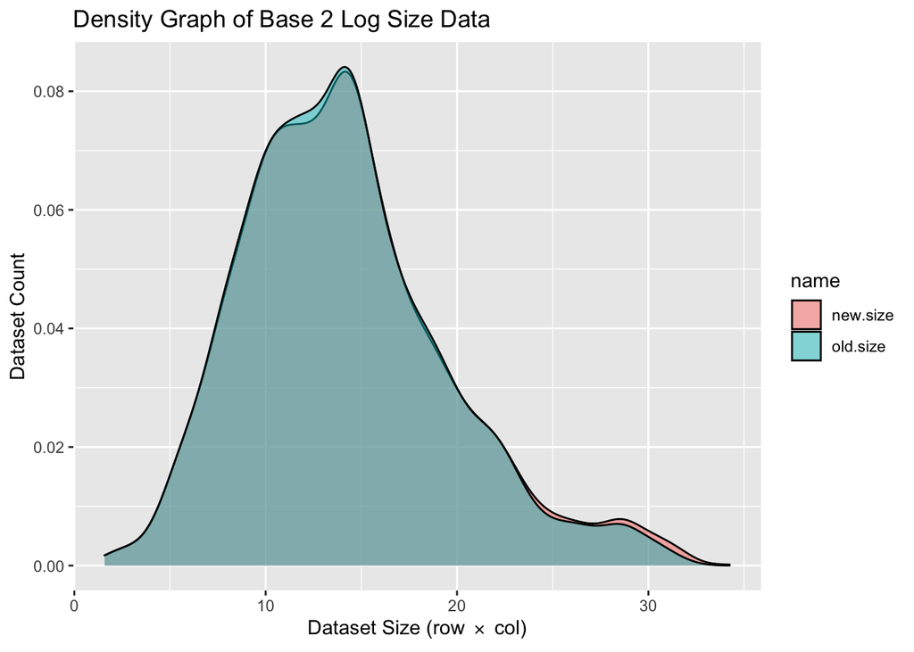

##### Minor Detour - What type of distribution does the size data fit? I wanted to see what type of distribution fits the size data. I knew there were some extreme values to deal with, especially after looking at the “as-is” graph and the underlying data too, and after the log-transform I wanted to see if this data is **log normal**. I used the package [EnvStats](https://cran.r-project.org/web/packages/EnvStats/index.html) to help analyze this data and to run some super basic tests.

```r
# A large stat package to help estimate distributions
library("EnvStats")

# Filter size data - remove NA and any ZEROs (there should be no negatives)
all_open_data_sets %>% dplyr::select(new.size) %>% filter(new.size>0) %>% na.omit() -> size_dist_test

# Unlist and formate data into vector for analysis
as.vector(as.numeric(unlist(size_dist_test))) -> size_dist_test

# A function to choose the best distribution for the dataset
distChoose(size_dist_test, warn=FALSE) -> size_dist_test

# Print results of distChoose() function
cat(paste(paste0("-------- distChoose() Output --------"),
          paste0("Choosen Distribution: ",size_dist_test$decision),
          str_squish(size_dist_test$test.results$norm$alternative),
          str_squish(size_dist_test$test.results$gamma$alternative),
          str_squish(size_dist_test$test.results$lnorm$alternative),
          sep="\n"));
```

```
## -------- distChoose() Output --------
## Choosen Distribution: Nonparametric
## True cdf does not equal the Normal Distribution.
## True cdf does not equal the Gamma Distribution.
## True cdf does not equal the Lognormal Distribution.
```

```r
# I need to detach this package since it has several functions that are the same
# as ones in dplyr and I don't want search for all duplicates.
detach("package:EnvStats", unload=TRUE)
```

In order to see if the dataset is lognormal I need to remove *0* and *NA* values, unlist (flatten) the dataset, convert to a vectored list of numbers. I used `EnvStats` library to analyzed the data and relied on two functions - `gofTest()` and `distChoose`. The function `gofTest()` only told me the data was not normal, so I moved on to `distChoice` which describes the data as “nonparametric” which basically means it does not fit any of the tested distributions.

I suspect that the reason for the lack of fit is the absence of low values sizes, and a few exceptionally large datasets. For example, the Parks Department table called “Daily Tasks Park Cleaning Records” is a large dataset with new.uid = “kwte-dppd”. This dataset has between 50 million (original uid) and 583 million rows (new.uid), depending non what uid is used. When `EnvStats` attempts to identify distribution the best describes the table sizes in the [Published Data Asset Inventory](https://data.cityofnewyork.us/resource/5tqd-u88y), it treats “Daily Tasks Park Cleaning Records” as though it were infinite and drops it.

In the interest of time I will put this analysis on pause and (perhaps) come back to this another time.

#### Datasets by Agency - Number, Visits, and Size

Most datasets that are not in Open Data Plan and seem to be released voluntarily. More than half of the datasets are not in the Open Data Plan.

Datasets Listed in the Open Data Plan

| from.opendata.plan | count | percent |
| --- | --- | --- |
| NO | 1,970 | 56.4% |
| YES | 1,523 | 43.6% |
| Total | 3,493 | 100.0% |

Let’s take a look at which agencies have released the most (and least) data. The three agencies that release the **most** data:

Agencies with Most Datasests

| dataset.owner | NO | YES | TOTAL | Pct_No |
| --- | --- | --- | --- | --- |
| DOE | 548 | 592 | 1,140 | 48.1% |
| DPR | 102 | 89 | 191 | 53.4% |
| DOT | 102 | 86 | 188 | 54.3% |
| DoITT | 177 | 9 | 186 | 95.2% |
| DCP | 103 | 25 | 128 | 80.5% |
| DOF | 91 | 32 | 123 | 74.0% |
| OPS | 66 | 12 | 78 | 84.6% |
| DOHMH | 33 | 44 | 77 | 42.9% |
| TLC | 66 | 6 | 72 | 91.7% |
| OMB | 35 | 32 | 67 | 52.2% |

Agencies with Fewest Datasets

| dataset.owner | NO | YES | TOTAL | Pct_No |
| --- | --- | --- | --- | --- |
| ADULTED | 1 | 0 | 1 | 100.0% |
| CLIMATE-POLICY | 1 | 0 | 1 | 100.0% |
| CUNY | 1 | 0 | 1 | 100.0% |
| HHS-ACCEL | 1 | 0 | 1 | 100.0% |
| MOCJ | 0 | 1 | 1 | 0.0% |
| OCC | 1 | 0 | 1 | 100.0% |
| OCME | 0 | 1 | 1 | 0.0% |
| OCMH | 0 | 1 | 1 | 0.0% |
| OTM | 1 | 0 | 1 | 100.0% |
| RECOVERY | 0 | 1 | 1 | 0.0% |

The table below (↓) summarizes all the “totals” for each agency - totals datasets, total visits, and total data. “Total Data” is really just the sum total of all matrix sizes (row x column) but “total data” is precise enough.

- Most datasets: DOE - 32% of all datasets
- Most visits: TLC - 27% of all visits
- Most data: TLC - 45% of all data

| dataset.owner | total_datasets | total_visits | total_size | avg_dataset_size | pct_total_dataset | pct_total_visit | pct_total_size |
| --- | --- | --- | --- | --- | --- | --- | --- |
| 311 | 15 | 538,335 | 6,025,139,757 | 401,675,984 | 0.4 | 2.4 | 5.6 |
| ACS | 18 | 18,913 | 6,877 | 382 | 0.5 | 0.1 | 0 |
| ADULTED | 1 | 1,230 | 189 | 189 | 0 | 0 | 0 |
| BIC | 9 | 91,153 | 74,936,777 | 8,326,309 | 0.3 | 0.4 | 0.1 |
| BOENY | 3 | 52,452 | 85,154 | 28,385 | 0.1 | 0.2 | 0 |
| BPBK | 21 | 5,728 | 47,992 | 2,285 | 0.6 | 0 | 0 |
| BPL | 2 | 3,342 | 0 | 0 | 0.1 | 0 | 0 |
| BPSI | 2 | 414 | 156 | 78 | 0.1 | 0 | 0 |
| BSA | 3 | 7,000 | 1,755,048 | 585,016 | 0.1 | 0 | 0 |
| CCHR | 3 | 1,345 | 654 | 218 | 0.1 | 0 | 0 |

[output cut: 86 more lines]

#### Total Datasets by Agnecy

Let’s see what the total data sets per agency look like. From the chart below we can see just how skewed the data is.

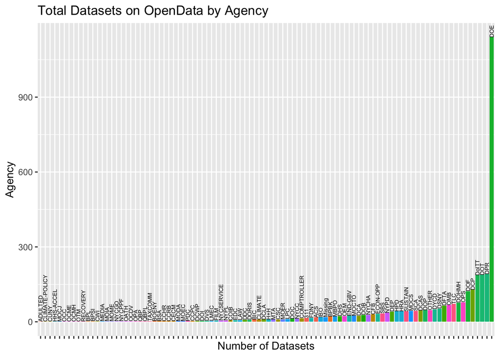

#### Decile Breakpoints

This is like a table version of the barchart above - it shows how skewed the dataset is for three measures.

1. Datasets per Agency: 90% of agencies have fewer than 66 datasets
2. Visits per Dataset: 90% of datasets have been viewed less than 6200 times
3. Size per Dataset: 90% of datasets have less than 122,000 rows (or 3,000,000) cells

Most of the information on OpenData isn’t accessed that often, and when a dataset is popular, it’s extremely popular. Everything about OpenData is skewed towards a few “winner” datasets.

Decile Breakpoints for Datasets, Views, Rows, and Cells

|  | 10% | 20% | 30% | 40% | 50% | 60% | 70% | 80% | 90% |
| --- | --- | --- | --- | --- | --- | --- | --- | --- | --- |
| Total Datasets per Agency | 1.5 | 2.0 | 3.0 | 5.0 | 9.0 | 16.0 | 24.5 | 42.0 | 66.0 |
| Total Views per Dataset | 127 | 176 | 251 | 354 | 498 | 741 | 1,172 | 2,214 | 6,268 |
| Total Rows per Dataset | 21 | 63 | 169 | 388 | 880 | 1,672 | 3,306 | 15,907 | 122,880 |
| Total Cells per Dataset | 180 | 678 | 1,680 | 4,615 | 12,201 | 25,657 | 69,984 | 309,114 | 3,058,605 |

#### Most Popular Datasets

Here we have the top 50 most visited datasets. Most of the popular datasets are somehow related to employment or business. The first five are related to employment - job applications, civil service results, and TLC datasets describing what drivers and vehicles are approved for work.

```r
# Top 50 most visited data sets
all_open_data_sets %>%
  dplyr::select( data.agency,dataset.owner,name,
         from.opendata.plan,
         update.freq,visits,row.new) %>%
  mutate(total.visit.rank = dense_rank(desc(as.numeric(visits)))) -> most_visited_data_sets

# Top 50 most visited data sets
most_visited_data_sets %>% filter(total.visit.rank <= 50) %>%
  mutate(visits = format(visits,big.mark=","),
         num.row = format(row.new,big.mark=",")) %>%
  select (-c(row.new)) %>% arrange(total.visit.rank) -> most_visited_data_sets

# HTML widget from DT
datatable(most_visited_data_sets,  class = 'cell-border stripe', caption = '50 Most Visited OpenData Tables',rownames = FALSE)
```

| data.agency | dataset.owner | name | from.opendata.plan | update.freq | visits | total.visit.rank | num.row |
| --- | --- | --- | --- | --- | --- | --- | --- |
| Department of Buildings (DOB) | DOB | DOB Job Application Filings | YES | Daily | 2,264,452 | 1 | 1,779,028 |
| Department of Citywide Administrative Services (DCAS) | DCAS | Civil Service List (Active) | NO | Daily | 1,976,992 | 2 | 572,093 |
| Taxi and Limousine Commission (TLC) | TLC | TLC New Driver Application Status | NO | Several times per day | 1,699,632 | 3 | 0 |
| Taxi and Limousine Commission (TLC) | TLC | For Hire Vehicles (FHV) - Active | NO | Daily | 1,562,524 | 4 | 94,962 |
| Taxi and Limousine Commission (TLC) | TLC | For Hire Vehicles (FHV) - Active Drivers | NO | Daily | 1,079,221 | 5 | 160,942 |
| 311 | 311 | 311 Service Requests from 2010 to Present | NO | Daily | 441,908 | 6 | 27,893,530 |
| Department of Citywide Administrative Services (DCAS) | DCAS | Civil Service List Certification | YES | Weekdays | 427,861 | 7 | 2,531,374 |
| Department of Buildings (DOB) | DOB | DOB Permit Issuance | NO | Daily | 397,673 | 8 | 3,790,130 |
| Taxi and Limousine Commission (TLC) | TLC | TLC Approved LabCorp Patient Services Drug Test Locations (Map) | NO | As needed | 358,462 | 9 | 40 |
| Police Department (NYPD) | NYPD | Motor Vehicle Collisions - Crashes | NO | Daily | 296,638 | 10 | 1,870,404 |

[output cut: 40 more lines]

#### Update Frequency

Below is a high level summary of dataset type and update frequency. The most visited tables are datasets and maps, but data that’s updated daily is also popular. Note that the `total.size` column is zero for some categories. The reason for this is that size is defined as ROWS x COLUMNS, which means that if a dataset doesn’t have these attributes it has “zero” size, when in reality it really does. An example of a dataset with “zero” size is a mapping layer - since it has no rows/columns size = 0 but the file consumes memory.

```r
# Most visited are datasets, followed by maps
all_open_data_sets %>% select(type,visits,new.size) %>%
  mutate_at( c("visits", "new.size"), ~replace(., is.na(.), 0)) %>%
  group_by(type) %>%
  summarize(count = n(),
            total.visits = sum(visits),
            total.size = sum(new.size)) %>%
  arrange(desc(total.visits)) %>%
  mutate(count = format(count,big.mark=","),
         total.visits = format(total.visits,big.mark=","),
         total.size = format(total.size,big.mark=",")) -> popular_type

# Format table
datatable(popular_type,  class = 'cell-border stripe', caption = 'Most Popular Data Type',rownames = FALSE,
          options=list(paging=FALSE,searching=FALSE))
```

| type | count | total.visits | total.size |
| --- | --- | --- | --- |
| dataset | 2,709 | 18,433,401 | 77,011,746,550 |
| map | 351 | 2,534,533 | 416,312,046 |
| href | 188 | 471,624 | 0 |
| file | 193 | 397,526 | 0 |
| datalens | 33 | 375,514 | 28,927,056,700 |
| filter | 19 | 281,376 | 1,338,825,418 |

```r
# Datasets that are updated daily are the most popular
all_open_data_sets %>% select(update.freq,visits,new.size) %>%
  mutate_at( c("visits", "new.size"), ~replace(., is.na(.), 0)) %>%
  group_by(update.freq) %>%
  summarize(count = n(),
            total.visits = sum(visits),
            total.size = sum(new.size)) %>%
  arrange(desc(total.visits)) %>%
  mutate(count = format(count,big.mark=","),
            total.visits = format(total.visits,big.mark=","),
            total.size = format(total.size,big.mark=",")) -> update_freq

# Format table
datatable(update_freq,  class = 'cell-border stripe', caption = 'Most Popular Update Frequency',
          rownames = FALSE, options=list(searching=FALSE))
```

| update.freq | count | total.visits | total.size |
| --- | --- | --- | --- |
| Daily | 112 | 10,637,444 | 14,100,896,624 |
| As needed | 680 | 3,423,341 | 23,360,196,787 |
| Historical Data | 1,372 | 2,103,297 | 56,069,036,310 |
| Several times per day | 4 | 1,763,260 | 1,526,736,579 |
| Annually | 667 | 1,675,325 | 3,674,978,455 |
| Monthly | 340 | 950,913 | 4,503,403,302 |
| Weekly | 62 | 566,514 | 284,727,271 |
| Weekdays | 5 | 551,914 | 169,354,611 |
| Quarterly | 109 | 525,071 | 1,542,894,913 |
| Biannually | 100 | 176,368 | 628,623,449 |

[output cut: 9 more lines]

#### Category

Similar to our findings on the agency with the most datasets, the category with the most data tables is Education. However, the largest and most popular datasets are for transportation.

```r
# Most popular category.
all_open_data_sets %>% select(category,visits,size) %>%
  group_by(category) %>% summarize(count = n(),
                                   avg_size = mean(size, na.rm=TRUE),
                                   avg_visits = mean(visits, na.rm=TRUE)) %>%
  mutate(category = ifelse(is.na(category),"NA",category),
         count = format(count,big.mark=","),
         avg_size = format(round(avg_size,digits=0),scientific = FALSE,big.mark=","),
         avg_visits = format(round(avg_visits,digits=0),big.mark=",")) -> category

# Format table
datatable(category,  class = 'cell-border stripe',
          caption = htmltools::tags$caption(style = 'caption-side: top; text-align: left;',
                                            'Most Popular Update Frequency'),
          rownames = FALSE, options=list(pageLength=15,paging=FALSE,searching=FALSE))
```

| category | count | avg_size | avg_visits |
| --- | --- | --- | --- |
| Business | 71 | 1,698,281 | 5,207 |
| City Government | 893 | 29,594,874 | 6,748 |
| Education | 1,177 | 195,051 | 909 |
| Environment | 192 | 4,647,626 | 4,032 |
| Health | 84 | 5,004,754 | 9,423 |
| Housing &amp; Development | 208 | 7,625,828 | 19,693 |
| NYC BigApps | 36 | 4,633 | 2,171 |
| Public Safety | 130 | 27,623,341 | 9,668 |
| Recreation | 84 | 35,098 | 2,395 |
| Social Services | 243 | 9,751,540 | 3,651 |

[output cut: 2 more lines]

#### Automation

Most data (around 85%) is not automated, thought a small and significant portion (around 15%) is automated.

```r
# Group and count data
all_open_data_sets %>% ungroup() %>% select(automated,can.automate) %>%
  group_by(automated,can.automate) %>%
  summarize(count = n(),.groups="keep") %>%
  ungroup() %>% mutate(freq = round(count / sum(count),2)) -> automation

# Format table
automation  %>% kbl(caption = "Automation Summary") %>%
  kable_styling(bootstrap_options = c("striped", "hover", "condensed", "responsive"),full_width = F)
```

Automation Summary

| automated | can.automate | count | freq |
| --- | --- | --- | --- |
| NO | NO | 2556 | 0.73 |
| NO | YES | 429 | 0.12 |
| YES | NO | 34 | 0.01 |
| YES | YES | 474 | 0.14 |

### Conclusion

#### Things to Change Next Time Around

- Reflow the analysis along these lines: (1) Intro; (2) Dataset Review (variable types and “peaks” at the data); (3) Data Cleaning (yes/no harmonizing); (4) New Variables (new uid, new size data, and the text-to-number function); (5) Distributions (density functions and tables); (6) Test and Fit (normality testing, best fit assessment); (7) Correlations (correlations and tables).
- Simpler “data.agency” name shortening.
- A simpler loop/apply method for cleaning yes/no values.
- Consistent tabling - I tested out too many different table format options.
- Clarify the uid/parent.uid analysis.
- The new size loop takes a long time to run - see if I can speed it up. > Some might be logical. Under what circumstances can I use the existing row/column count information? most of my new row/column counts were the same as the old one. I unintentionally pulled all uids to see how off my method might be, but now it needs to be optimized for speed. > Some might be coding. What fields can I access faster than pulling the first 200 rows to get column data? Is there an alternative to select(*) for row counts?
- Improve the text_to_num_recode() function. I would like the function to create a recode dictionary data.frame to hold the old/new values. I would also like to have different recoding options - alphabetical sorting; large-to-small sorting based on total values for each field value; an arbitrary, user-defined list.
- Simplier column-name shortening - I don’t want to list every item to recode.
- A better statistical analysis and review section. Spend more time evaluating best-fit options for various fields.

## Citations

This is not an exhaustive list of web-pages that helped me prepare this analysis, but it captures some of the most important references.

1. https://universeofdatascience.com/how-to-recode-character-variables-in-r/
2. https://docs.google.com/document/d/185lRocur3g-EyvXIUnYXNITSPp0hcB9wQ7DsA7Hvl3M/edit
3. https://opendata.cityofnewyork.us/how-to/
4. https://dev.socrata.com/consumers/getting-started.html
5. https://dev.socrata.com/docs/queries/
6. https://dev.socrata.com/docs/endpoints.html
7. https://github.com/njtierney/rmd-errors
8. https://stackoverflow.com/questions/29274501/r-markdown-changing-font-size-and-font-type-in-html-output
9. https://rstudio.github.io/DT/
10. https://stackoverflow.com/questions/8161836/how-do-i-replace-na-values-with-zeros-in-an-r-dataframe
11. http://www.wu.ece.ufl.edu/links/dataRate/DataMeasurementChart.html
12. https://rc2e.com/rmarkdown
13. https://stackoverflow.com/questions/12834861/access-local-dataframe-outside-the-function-in-r
14. https://stackoverflow.com/questions/2641653/pass-a-data-frame-column-name-to-a-function
15. https://r-lang.com/not-in-r/
16. https://www.datanovia.com/en/blog/easy-correlation-matrix-analysis-in-r-using-corrr-package/
17. https://bwlewis.github.io/covar/missing.html
18. https://themockup.blog/static/slides/intro-tables-urban.html
19. http://www.sthda.com/english/wiki/normality-test-in-r
20. https://bookdown.org/yihui/rmarkdown-cookbook/
21. https://cran.r-project.org/web/packages/corrplot/vignettes/corrplot-intro.html

## Appendix A

### Useful Bits of Code

- Use `"eval = FALSE"` in the markdown header to include/print code but not execute it.
- Use this code to copy data to Excel in a **Mac**.  
  `# Mac - Copy data to Excel via Clipboards`  
  `clip <- pipe("pbcopy", "w")`  
  `write.table(dataframe, file=clip, sep = '\t', row.names=FALSE,col.names=TRUE)`  
  `close(clip)`
- Use this code to copy data to Excel in **Windows**.  
  `write.table(dataframe,"clipboard",sep="\t",row.names=FALSE,col.names=TRUE)`
- Change [font color](https://bookdown.org/yihui/rmarkdown-cookbook/font-color.html) in RMarkdown. `colorize <- function(x, color) {if (knitr::is_latex_output()) {sprintf("\\textcolor{%s}{%s}", color, x)}` `else if (knitr::is_html_output()) {sprintf("<span style='color: %s;'>%s</span>", color,x)} else x}`

## Appendix B

### Data Distributions & Correlations

What correlations are there in this table for fields with discreet and meaningful values? We’ll focus this analysis on yes/no fields, size, visits, and dataset owners.

Here’s the work plan: 1. Recode all text values as numbers. a. For example - recode “update.freq” so that “Annually” = 1, “Historical Data” = 2, etc. b. Write a function to do this. 2. Run a `cor` on the recoded matrx. See what’s correlated. 3. See if there is any data to support this hypothesis: There is a positive correlation between: a. Visits and Update Frequency (NO - Fail to find a correlation that’s significant) b. Visits and Geo Coding (NO - Fail to find a correlation that’s significant) c. Visits and Dataset Owner (YES - Find a correlation that’s significant but small)

After the correlation review, we’ll review density curves for visits and investigate whether the visit data is normal or not (spoiler - it’s not).

```r
# Load Libraries
library(corrplot) # correlation matrix graphics
library(corrr) # big correlations
library(ggpubr)
library(EnvStats)

# Create a series of normal random numbers
norm <- rnorm(1000)

# Define not in operator
`%!in%` <- Negate(`%in%`)

# Define a function to recode text values to numbers for a correlation matrix
text_to_num_recode <- function(df1,col1){
  oldvals <- as.list(sort(unique(df1[,col1])))
  newvals <- seq.int(length(oldvals))
  match_list <- newvals[match(df1[,col1], oldvals)]
  new_name <- paste0(col1,"_num")
  df1[new_name] <- match_list
  return(df1)
}

# Select data to recode
all_open_data_sets %>%
  select(visits,new.size,from.opendata.plan,automated,can.automate,
         has.dictionary,contain.address,geo.coded,exists.externally,
         records.removed,automated,can.automate,from.opendata.plan,
         has.dictionary,contain.address,geo.coded,exists.externally,
         records.removed,dataset.owner,type,category,update.freq) -> all_open_data_sets_recode

# List of colnames to process
list_to_recode <- colnames(all_open_data_sets_recode)[colnames(all_open_data_sets_recode) %!in%
                                                        c('visits','new.size')]

# Loop through list of columns to recode
for (i in list_to_recode){
  all_open_data_sets_recode <- text_to_num_recode(all_open_data_sets_recode,i)
}

# Add "_num" to visits and new.size to keep in the next step
colnames(all_open_data_sets_recode)[which(names(all_open_data_sets_recode) == "visits")] <- "visits_num"
colnames(all_open_data_sets_recode)[which(names(all_open_data_sets_recode) == "new.size")] <- "new.size_num"

# Drop columns without "_num" in the name (this removes the text values)
all_open_data_sets_recode <- all_open_data_sets_recode[,grepl("_num",names(all_open_data_sets_recode))]
to_drop <- apply(all_open_data_sets_recode,1,function(x) any(x>0))
all_open_data_sets_recode <- all_open_data_sets_recode[to_drop,]

# Add normal random data to a column
all_open_data_sets_recode$norm.rand_num <- rnorm(nrow(all_open_data_sets_recode))

# Shorten names so labels will fit in graphics
names(all_open_data_sets_recode)[names(all_open_data_sets_recode) == 'visits_num'] <- 'vist'
names(all_open_data_sets_recode)[names(all_open_data_sets_recode) == 'new.size_num'] <- 'size'
names(all_open_data_sets_recode)[names(all_open_data_sets_recode) == 'from.opendata.plan_num'] <- 'plan'
names(all_open_data_sets_recode)[names(all_open_data_sets_recode) == 'automated_num'] <- 'auto'
names(all_open_data_sets_recode)[names(all_open_data_sets_recode) == 'can.automate_num'] <- 'cato'
names(all_open_data_sets_recode)[names(all_open_data_sets_recode) == 'has.dictionary_num'] <- 'dict'
names(all_open_data_sets_recode)[names(all_open_data_sets_recode) == 'contain.address_num'] <- 'addr'
names(all_open_data_sets_recode)[names(all_open_data_sets_recode) == 'geo.coded_num'] <- 'geo'
names(all_open_data_sets_recode)[names(all_open_data_sets_recode) == 'exists.externally_num'] <- 'xtrn'
names(all_open_data_sets_recode)[names(all_open_data_sets_recode) == 'records.removed_num'] <- 'rmvd'
names(all_open_data_sets_recode)[names(all_open_data_sets_recode) == 'dataset.owner_num'] <- 'own'
names(all_open_data_sets_recode)[names(all_open_data_sets_recode) == 'type_num'] <- 'type'
names(all_open_data_sets_recode)[names(all_open_data_sets_recode) == 'category_num'] <- 'cat'
names(all_open_data_sets_recode)[names(all_open_data_sets_recode) == 'update.freq_num'] <- 'freq'
names(all_open_data_sets_recode)[names(all_open_data_sets_recode) == 'norm.rand_num'] <- 'rand'

# Calculate large correlation matrix
open_data_corr = cor(all_open_data_sets_recode,use="pairwise.complete.obs")

# Calculate significance
testRes = cor.mtest(all_open_data_sets_recode, conf.level = 0.95)
```

#### A Trimmed Correlation Matrix

Significant coefficients are left visible, non-significant coefficients are left blank. The confidence interval used 95%. Unfortunately the results are not particularly interesting.

- “Can Automate” is correlated with “Automated” (cato, auto): Not too useful and a bit of a tautology - if a thing is automated it means it is automatable.
- “Geocoded” is highly correlated with “Address” (geo, addr): Also not too useful. Geocodes and addresses are similar, if you have one you can frequently derive the other.

The one correlation that grabs my eye is the one between dataset size (size) and the dataset’s owner (own). This is small and positive. One area for further study might be to look at correlation matrices for each owner. I predict that transportation an education agencies will have differences that point towards agencies voluntarily releasing large datasets with good documentation.

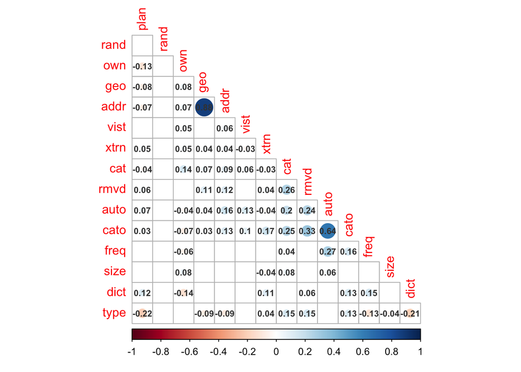

#### A Full Correlation Matrix

All coefficients are left visible in this table.

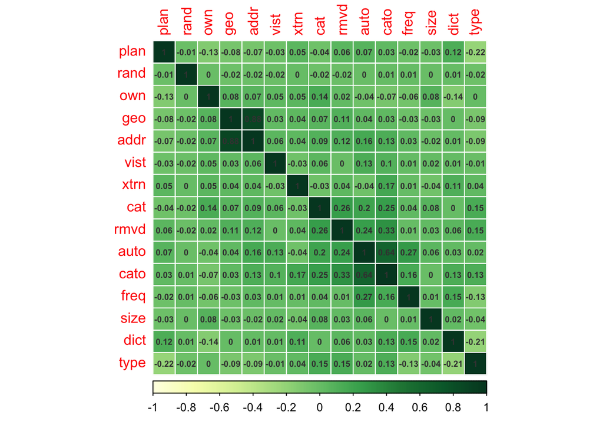

#### Density Curves

A [Density plot](https://en.wikipedia.org/wiki/Probability_density_function) displays the distribution of numeric values. For a given point on the line of the curve, the *y* value represents the share of objects located at point *x*. Given a vertical line (parallel to the y-axis) that passes through the density curve, the total area to the left of the line represents the total share of observations at or below the point the vertical line passes through x-axis.

The normal distribution is **black**, the raw visit data is green and the log transformed visit data is red.

The raw visit data does not look normal at all, but the log transformation looks considerably more normal, though it has a significant right/positive skew.

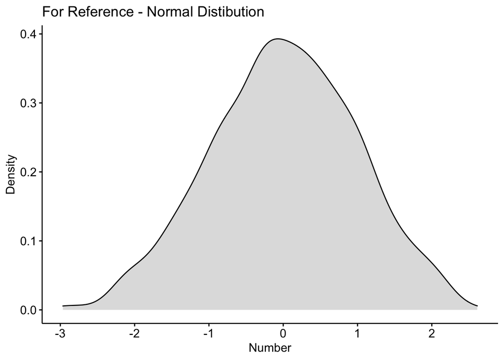

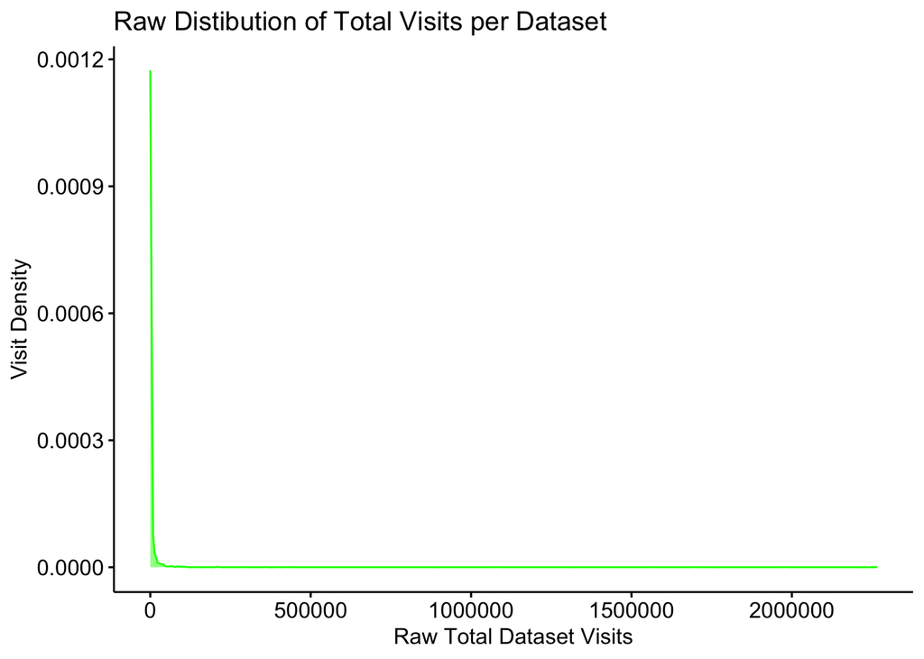

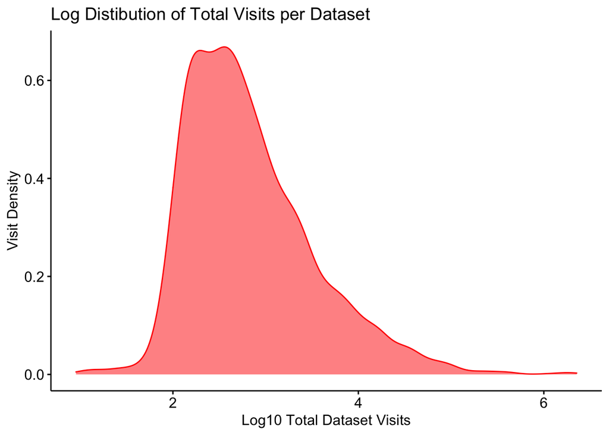

#### Q-Q Plots

A [Q-Q plot](https://en.wikipedia.org/wiki/Q–Q_plot) compares the probability distributions of two plots against each other. A 45-degree line is included to show where the points should appear if the two distributions are equal.

None of the size distributions examined come close to lining up on the 45-degree line, though the log transformations (the red and blue graphs) come closer to normal (**black**) than the raw data (green)

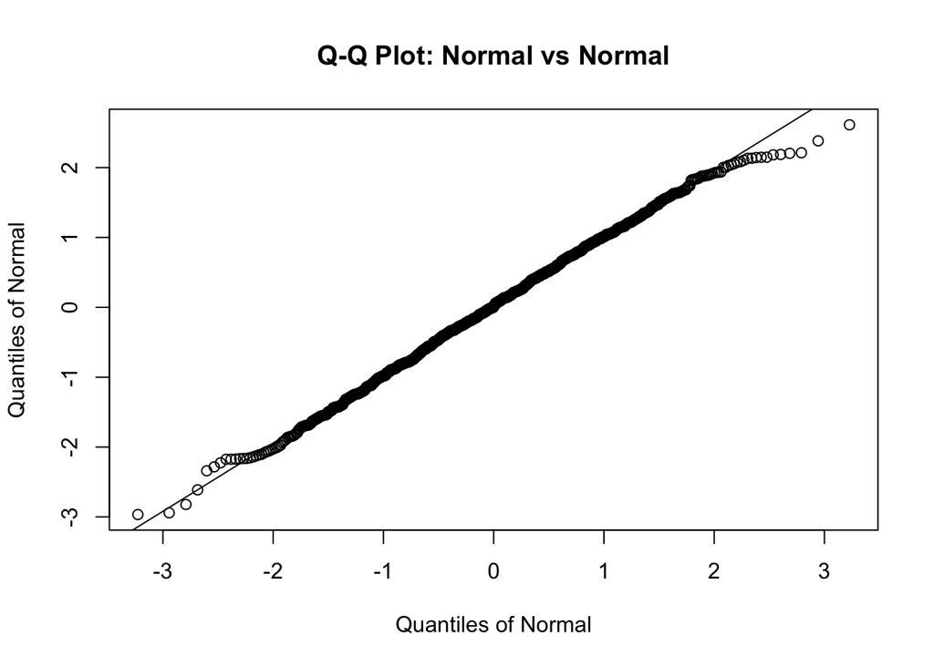

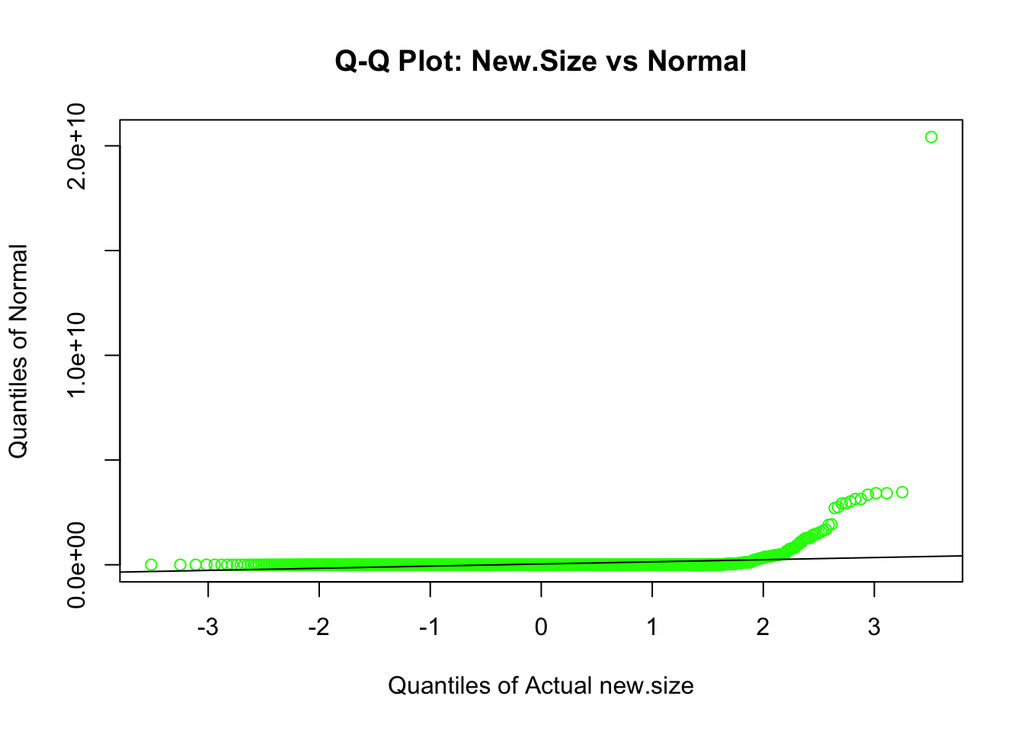

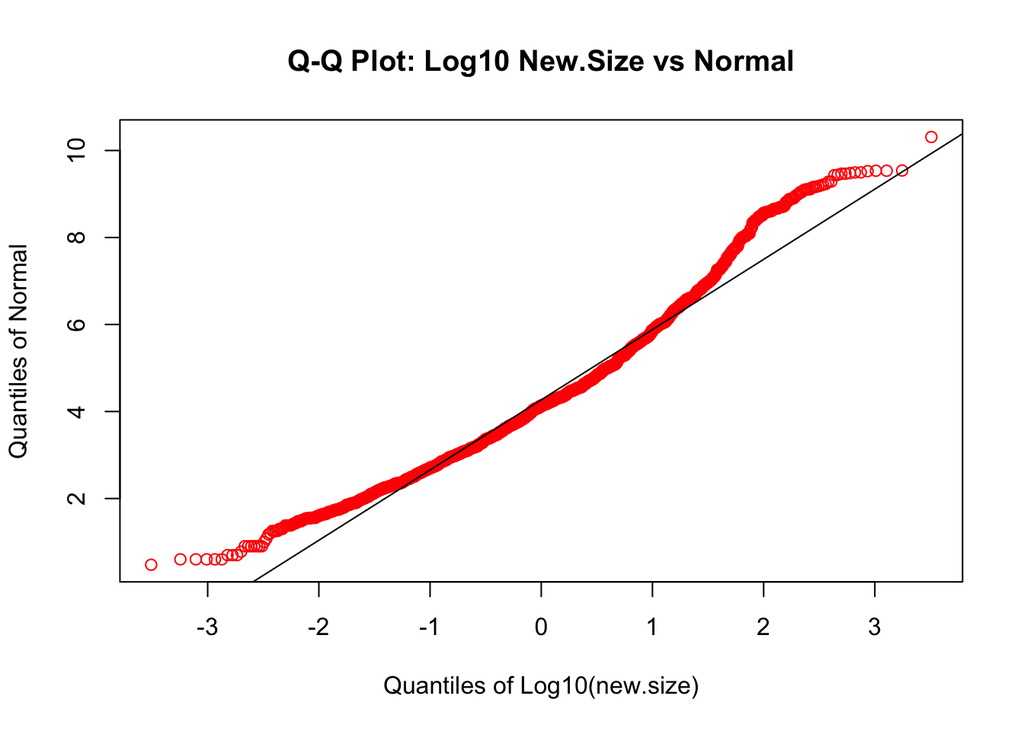

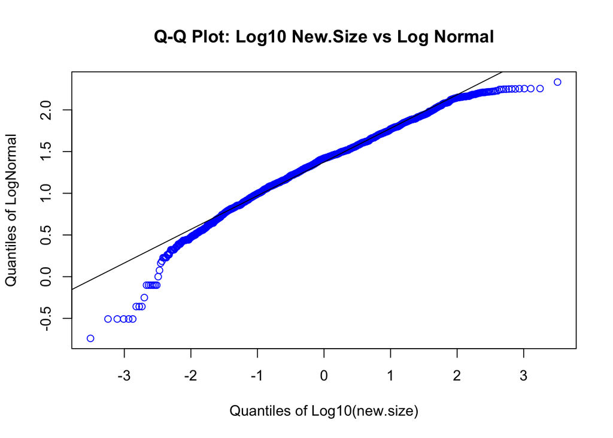

#### Normality Test

We’ve already used density graphs and Q-Q plots to graphically examine the distributions of our Visit and Size data elements. Visuals can help guide but for precise work we need a statistical test of normality. There are [several normality tests](https://en.wikipedia.org/wiki/Normality_test) but I’ll use the *Shapiro-Wilk normality test* in R. I performed this test on normal data, the visit and size data, and log transformations of the visit and size data.

The data element we’ll focus on is the p-value. If the p-value for a dataset is > 0.05 then the we can not reject the hypothesis that the dataset distribution is different from normal, which means the dataset is normally distributed.

Shapiro-Wilk normality test

| data.name | p.value | statistic |
| --- | --- | --- |
| Normal | 5.04e-02 | 0.9969 |
| Visits | 2.98e-85 | 0.0518 |
| Log10(Visits) | 2.93e-35 | 0.9408 |
| Size | 5.88e-80 | 0.0537 |
| Log10(Size) | 9.29e-38 | 0.9117 |